# matching

Francisco d’Albertas

2022-01-18

## Modificacoes discutidas

- usar classe de pastagem como: 0-0.25 ou 0.3; 0.25-1
- desconsiderar propriedades pequenas da razao vegetacao
- usar proporcao RL como variavel categorica
  - fazer intervalo de 0.18-0.22 e avaliar distribuicao
- usar ratio grande pra controle, bem mais que 1.

## Pareando as propriedades certificadas e nao certificadas

### Variaveis do modelo

A data mais antiga é 2009, logo consideramos os 5 anos anteriores para o matching.

- desmatamento acumulado entre 2004 e 2009;
- presença de RL;
- bioma;
- regeneração acumulada entre 2004 e 2009;
- área da propriedade;
- declividade média;
- proporção de pastagem 2009;
- proporção de vegetação nativa 2009;

*OBS:*

- os dados de cobertura de floresta e pastagem sao da colecao 5.

Distribuicao de propriedades certificadas entre MA e CE:

```
##        CERRADO MATA ATLÂNTICA
##            365            172
```

Distribuição de tamanho das propriedades de forma categorica (large, medium, small)

```
##     l     m     s
##   997  5542 57836
```

Distribuição da proporcao de pastagens de forma categorica:

- Aqui usar 2 classes (0-0.25;0.25-1)

```
## (-0.1,0.25]  (0.25,1.1]
##       20629       43746
```

## Modelos

```r
# formula com slope

formula <- treatment ~ desm_ac + LR_bin + propAPP +area_im_mf + prop_veg_09  + prop_past_09_ct+ mean_slope

# formula sem slope (pro cerrado pode valer a pena)

formula2 <- treatment ~ desm_ac + LR_bin + propAPP +area_ct + prop_veg_09  + prop_past_09

# formula com APP categorico

formula3 <- treatment ~ desm_ac + LR_bin + propAPP_ct +area_ct + prop_veg_09  + prop_past_09

# formula com veg categorico

formula4 <- treatment ~ desm_ac + LR_bin + propAPP +area_ct + prop_veg_09_ct  + prop_past_09

# formula com veg categorico

formula5 <- treatment ~ desm_ac + LR_bin + propAPP +area_ct + prop_veg_09  + prop_past_09_ct

# formula com area im cat

formula6 <- treatment ~ desm_ac + LR_bin + propAPP +area_ct + prop_veg_09  + prop_past_09_ct+ mean_slope + reg_ac
```

Após testar diferentes formulas, verificamos que o modelo 6 apresenta o melhor pareamento. Nesse modelo, a proporção de pastagem e o tamanho das propriedades foram tratados de forma categorica (**discutir isso**)

### Distribuicao das variaveis

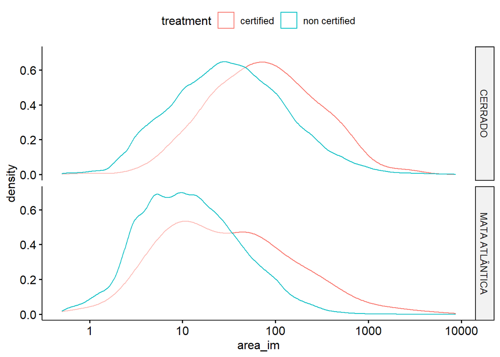

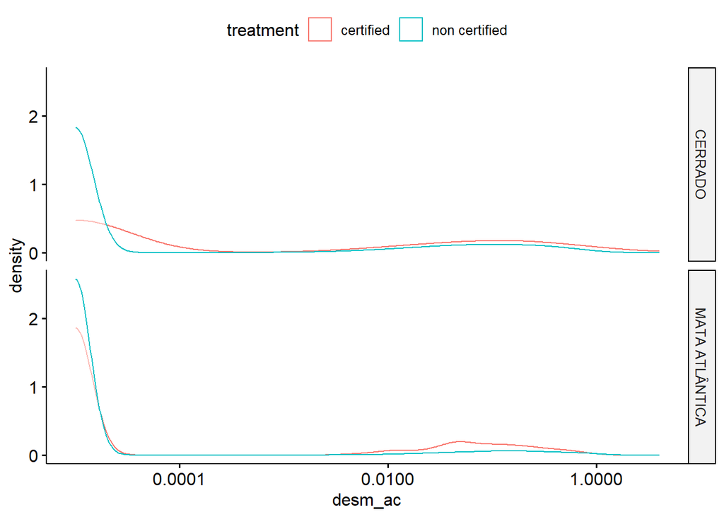

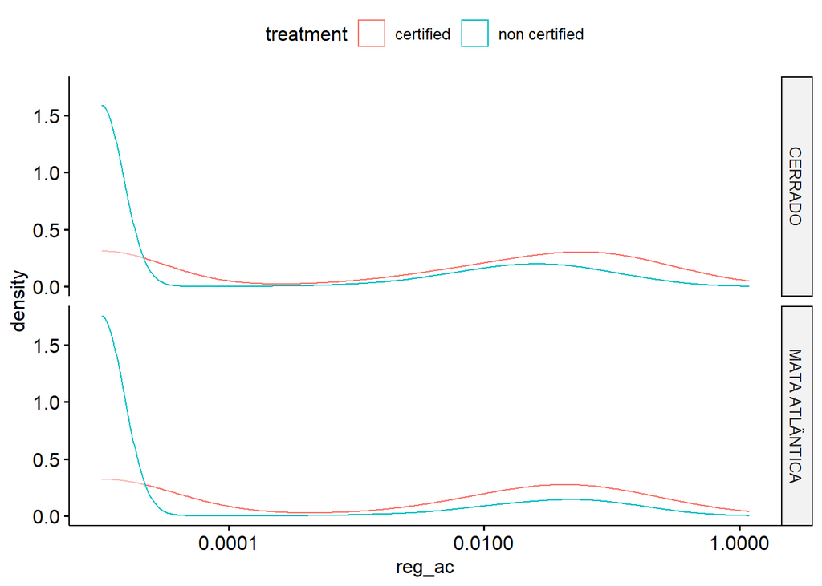

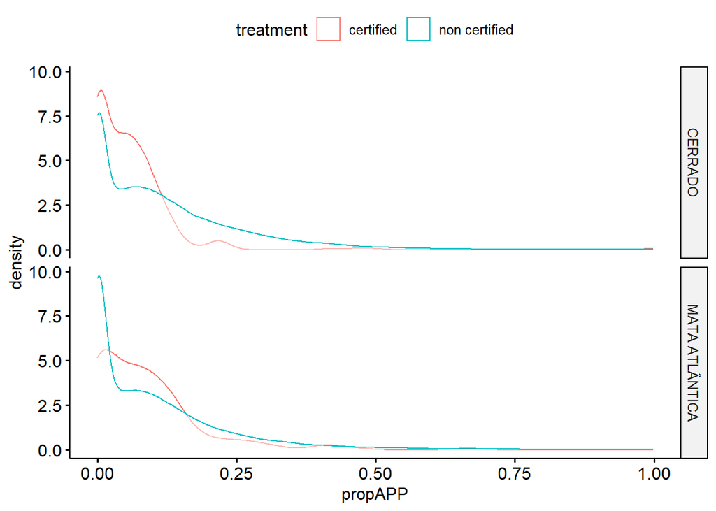

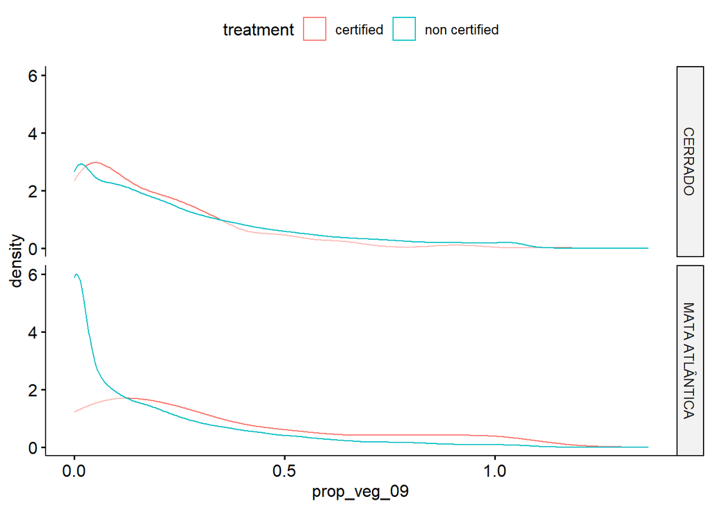

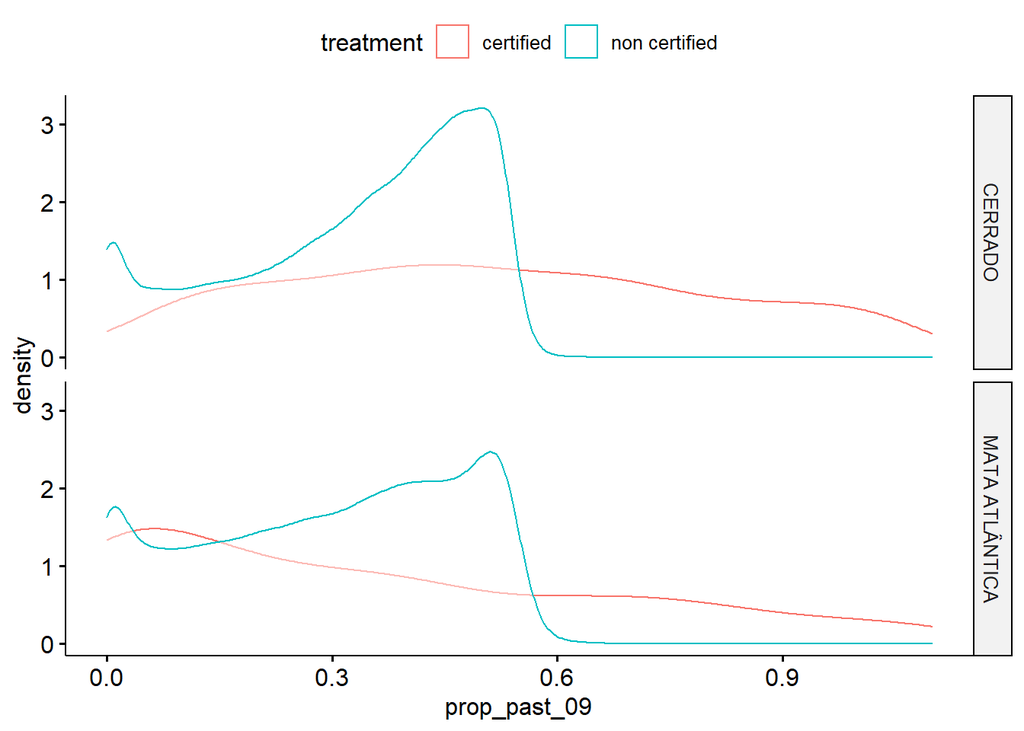

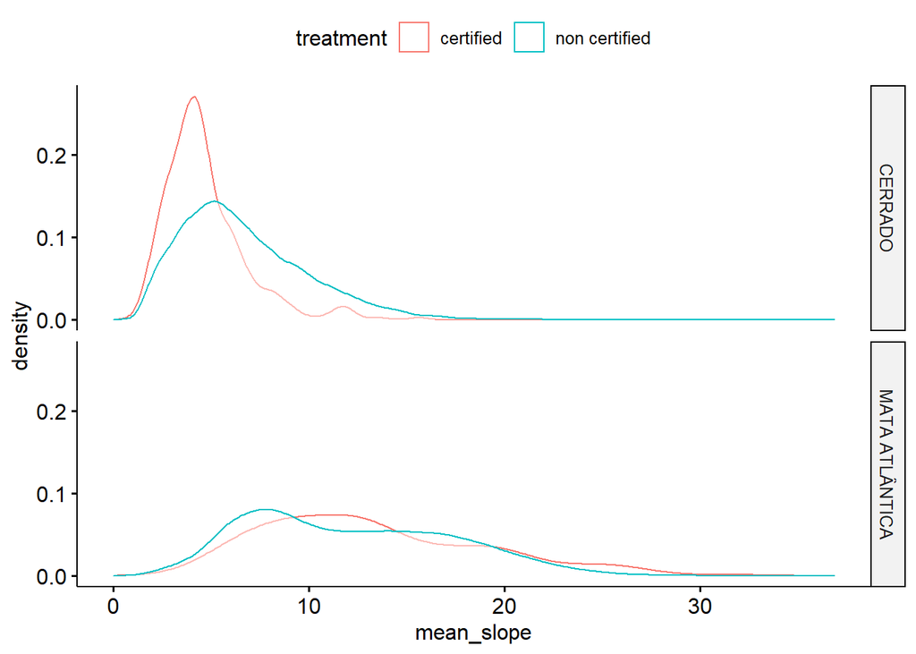

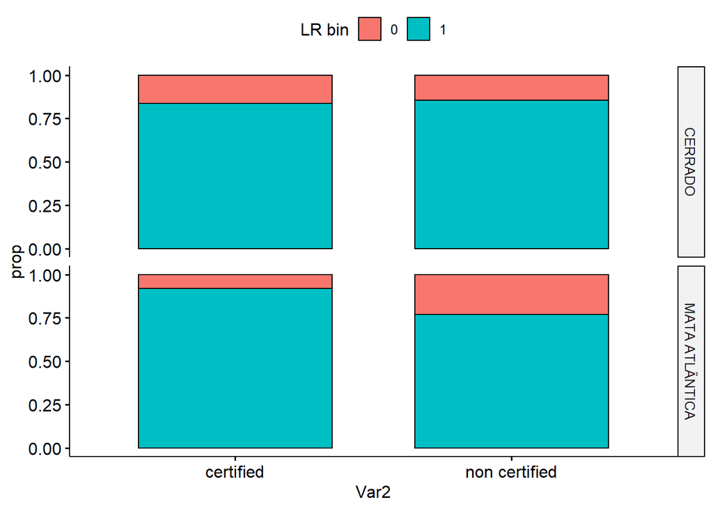

### Modelo para a mata atlântica:

```r
nn_ma <-matchit(formula6, data=df_ma, method="nearest", ratio=5, caliper = 0.25,replace = T)

summary(nn_ma, standardize = TRUE)
```

```
##
## Call:
## matchit(formula = formula6, data = df_ma, method = "nearest",
##     replace = T, caliper = 0.25, ratio = 5)
##
## Summary of Balance for All Data:
##                            Means Treated Means Control Std. Mean Diff.
## distance                          0.0248        0.0070          0.4288
## desm_ac                           0.0350        0.0201          0.1475
## LR_bin0                           0.0814        0.2308         -0.5465
## LR_bin1                           0.9186        0.7692          0.5465
## propAPP                           0.0861        0.1080         -0.2216
## area_ctl                          0.0756        0.0039          0.2711
## area_ctm                          0.1453        0.0458          0.2826
## area_cts                          0.7791        0.9503         -0.4127
## prop_veg_09                       0.3381        0.1793          0.5137
## prop_past_09_ct(-0.1,0.25]        0.4884        0.3799          0.2169
## prop_past_09_ct(0.25,1.1]         0.5116        0.6201         -0.2169
## mean_slope                       13.2438       12.1266          0.2000
## reg_ac                            0.0334        0.0160          0.2913
##                            Var. Ratio eCDF Mean eCDF Max
## distance                      15.5088    0.2411   0.3624
## desm_ac                        0.9965    0.0619   0.1610
## LR_bin0                             .    0.1494   0.1494
## LR_bin1                             .    0.1494   0.1494
## propAPP                        0.5106    0.0538   0.1176
## area_ctl                            .    0.0716   0.0716
## area_ctm                            .    0.0996   0.0996
## area_cts                            .    0.1712   0.1712
## prop_veg_09                    1.8628    0.2077   0.2686
## prop_past_09_ct(-0.1,0.25]          .    0.1084   0.1084
## prop_past_09_ct(0.25,1.1]           .    0.1084   0.1084
## mean_slope                     1.1193    0.0543   0.1139
## reg_ac                         1.1788    0.1583   0.3121
##
##
## Summary of Balance for Matched Data:
##                            Means Treated Means Control Std. Mean Diff.
## distance                          0.0221        0.0221          0.0006
## desm_ac                           0.0349        0.0298          0.0504
```

[output cut: 34 more lines]

```
## area_ctm                              95.2          .      95.2     95.2
## area_cts                              88.5          .      88.5     88.5
## prop_veg_09                           91.9       92.5      88.2     75.3
## prop_past_09_ct(-0.1,0.25]            96.0          .      96.0     96.0
## prop_past_09_ct(0.25,1.1]             96.0          .      96.0     96.0
## mean_slope                            97.0       25.3      47.3      6.8
## reg_ac                                79.9     -823.6      33.1     38.4
##
## Sample Sizes:
##                Control Treated
## All           23906.       172
## Matched (ESS)   662.16     169
## Matched         764.       169
## Unmatched     23142.         3
## Discarded         0.         0
```

### Modelo para o cerrado:

```
##
## Call:
## matchit(formula = formula6, data = df_ce, method = "nearest",
##     replace = T, caliper = 0.25, ratio = 5)
##
## Summary of Balance for All Data:
##                            Means Treated Means Control Std. Mean Diff.
## distance                          0.0270        0.0089          0.4998
## desm_ac                           0.0693        0.0339          0.2147
## LR_bin0                           0.1616        0.1456          0.0437
## LR_bin1                           0.8384        0.8544         -0.0437
## propAPP                           0.0566        0.1260         -0.8757
## area_ctl                          0.0740        0.0216          0.2001
## area_ctm                          0.2247        0.1087          0.2778
## area_cts                          0.7014        0.8697         -0.3678
## prop_veg_09                       0.1958        0.2632         -0.3472
## prop_past_09_ct(-0.1,0.25]        0.2082        0.2851         -0.1894
## prop_past_09_ct(0.25,1.1]         0.7918        0.7149          0.1894
## mean_slope                        4.6872        6.6673         -0.9408
## reg_ac                            0.0508        0.0163          0.3714
##                            Var. Ratio eCDF Mean eCDF Max
## distance                       7.5178    0.2854   0.4311
## desm_ac                        2.0921    0.0941   0.1591
## LR_bin0                             .    0.0161   0.0161
## LR_bin1                             .    0.0161   0.0161
## propAPP                        0.3167    0.1808   0.3107
## area_ctl                            .    0.0524   0.0524
## area_ctm                            .    0.1159   0.1159
## area_cts                            .    0.1683   0.1683
## prop_veg_09                    0.5772    0.0719   0.1260
## prop_past_09_ct(-0.1,0.25]          .    0.0769   0.0769
## prop_past_09_ct(0.25,1.1]           .    0.0769   0.0769
## mean_slope                     0.4261    0.1985   0.3492
## reg_ac                         3.3542    0.2142   0.2976
##
##
## Summary of Balance for Matched Data:
##                            Means Treated Means Control Std. Mean Diff.
## distance                          0.0250        0.0250         -0.0004
## desm_ac                           0.0692        0.0589          0.0623
```

[output cut: 34 more lines]

```
## area_ctm                              91.1          .      91.1     91.1
## area_cts                              93.8          .      93.8     93.8
## prop_veg_09                           85.7       82.0      62.7     52.9
## prop_past_09_ct(-0.1,0.25]            84.9          .      84.9     84.9
## prop_past_09_ct(0.25,1.1]             84.9          .      84.9     84.9
## mean_slope                            97.9       81.6      87.1     77.2
## reg_ac                                87.4       55.3      42.7     41.2
##
## Sample Sizes:
##                Control Treated
## All           39932.       365
## Matched (ESS)  1527.56     362
## Matched        1675.       362
## Unmatched     38257.         3
## Discarded         0.         0
```

### Analisando ajuste dos modelos

#### Mata Atlântica

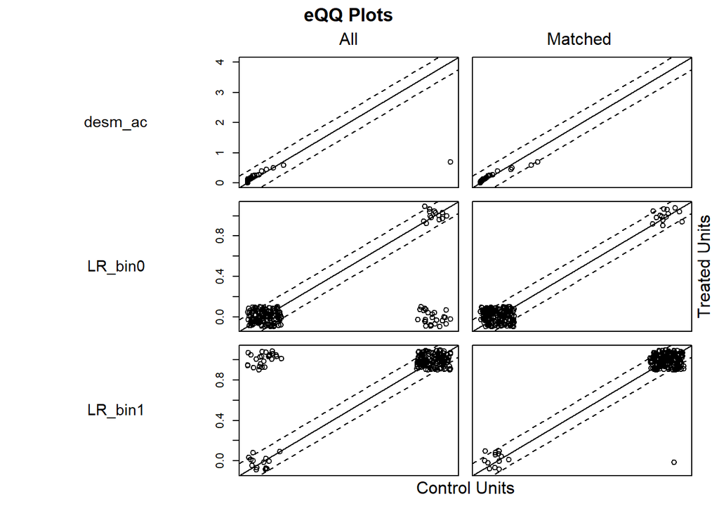

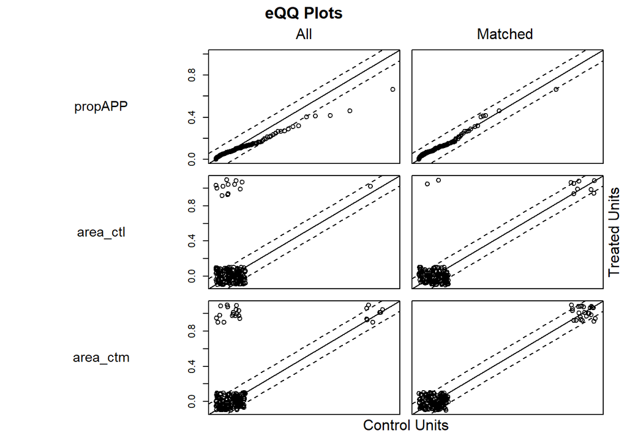

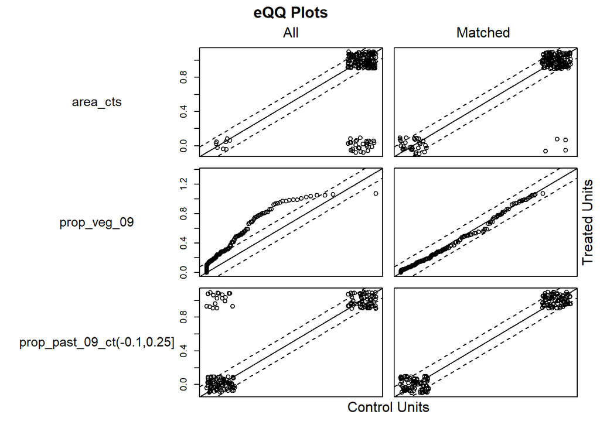

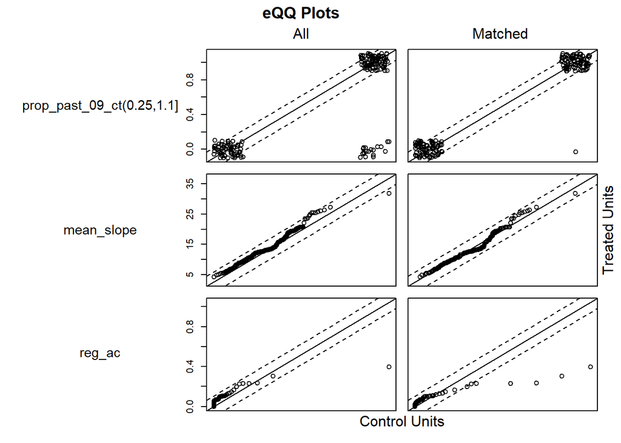

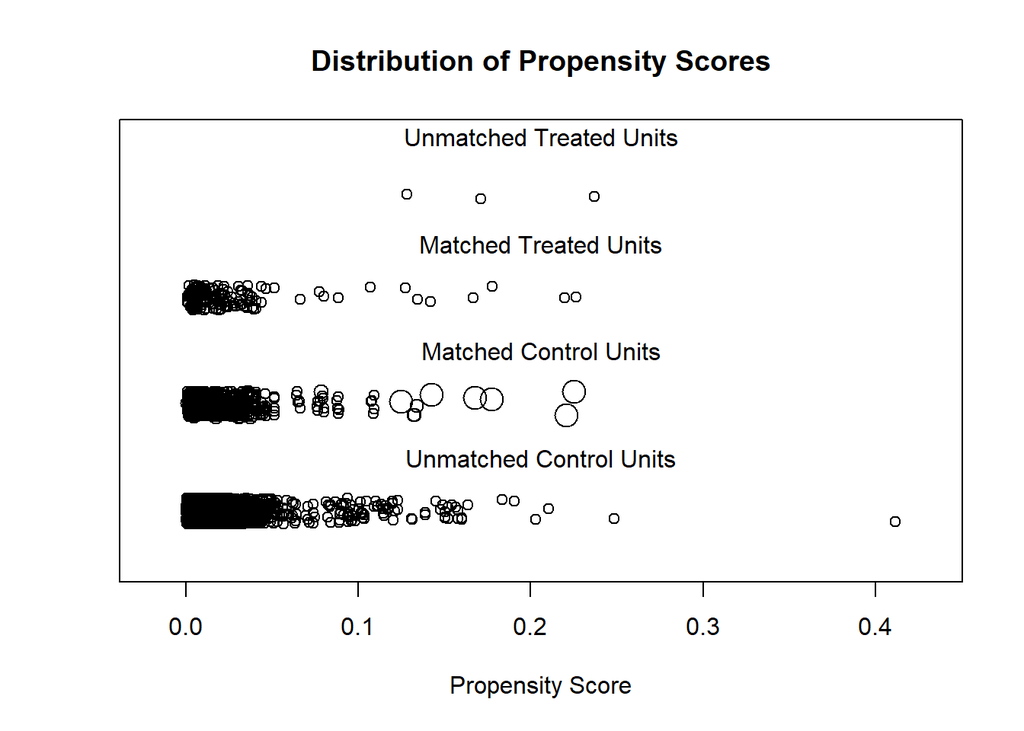

```
## [1] "To identify the units, use first mouse button; to stop, use second."
```

```
## integer(0)
```

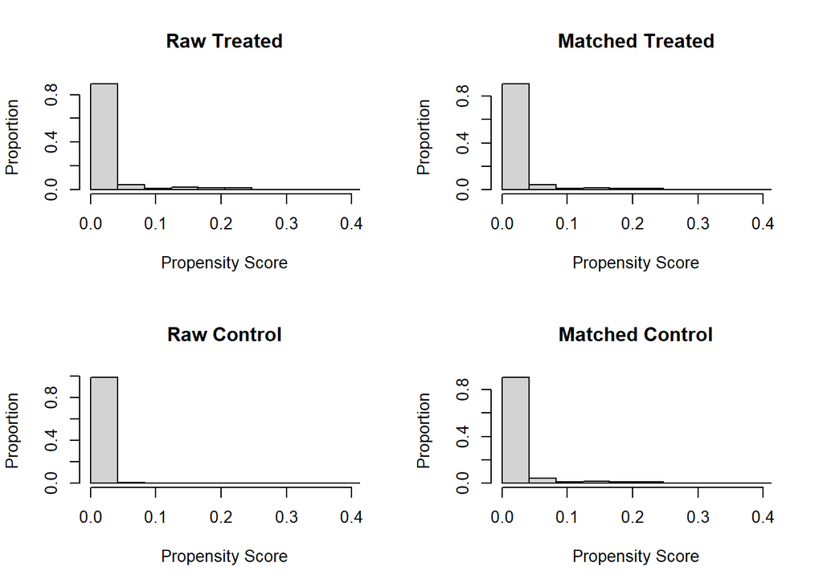

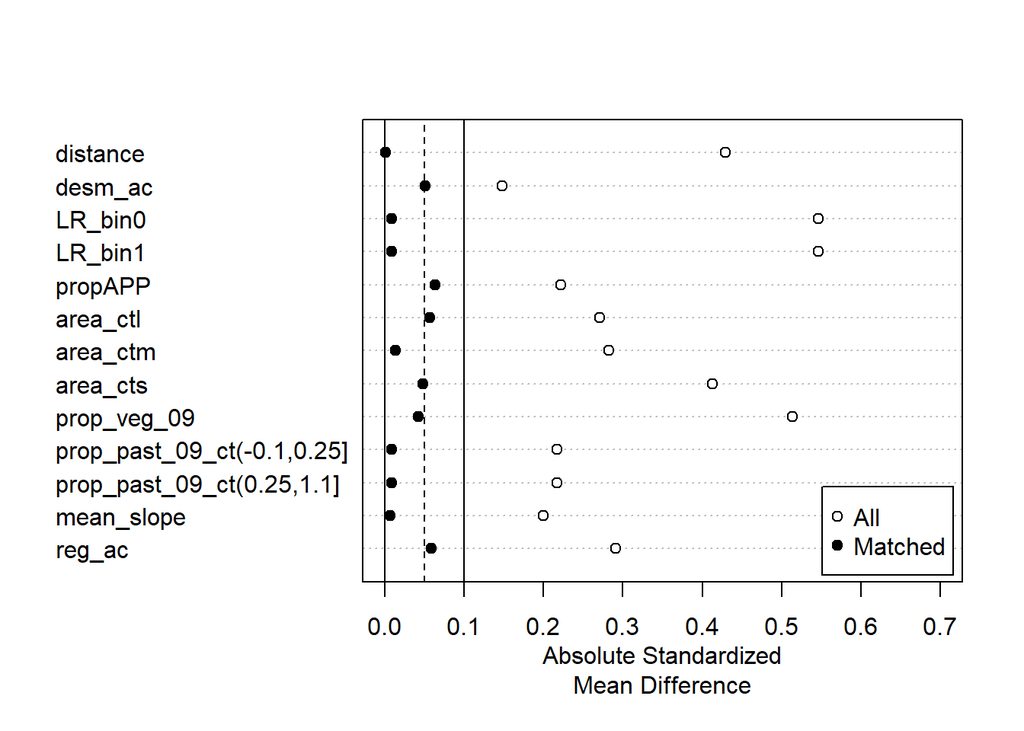

#### CE

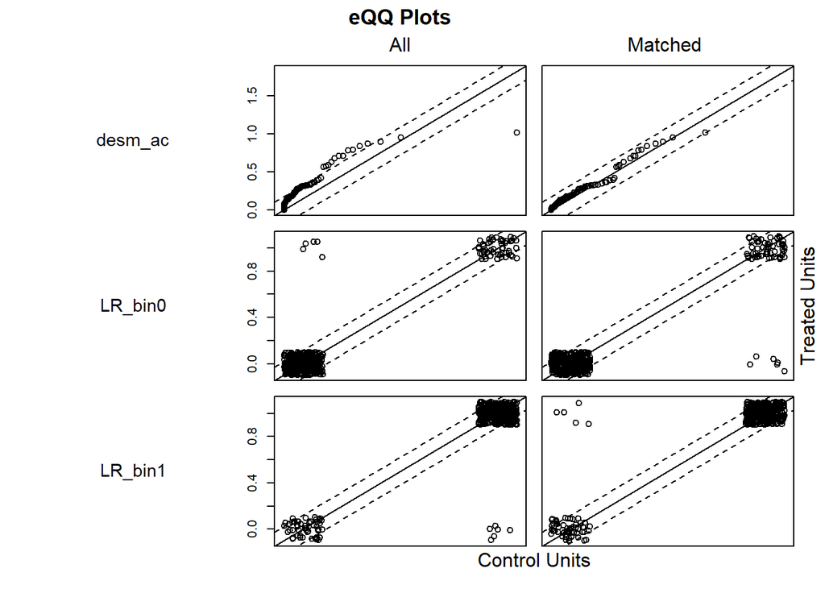

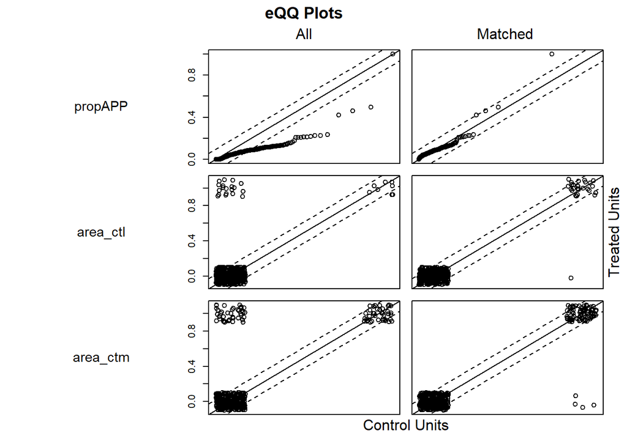

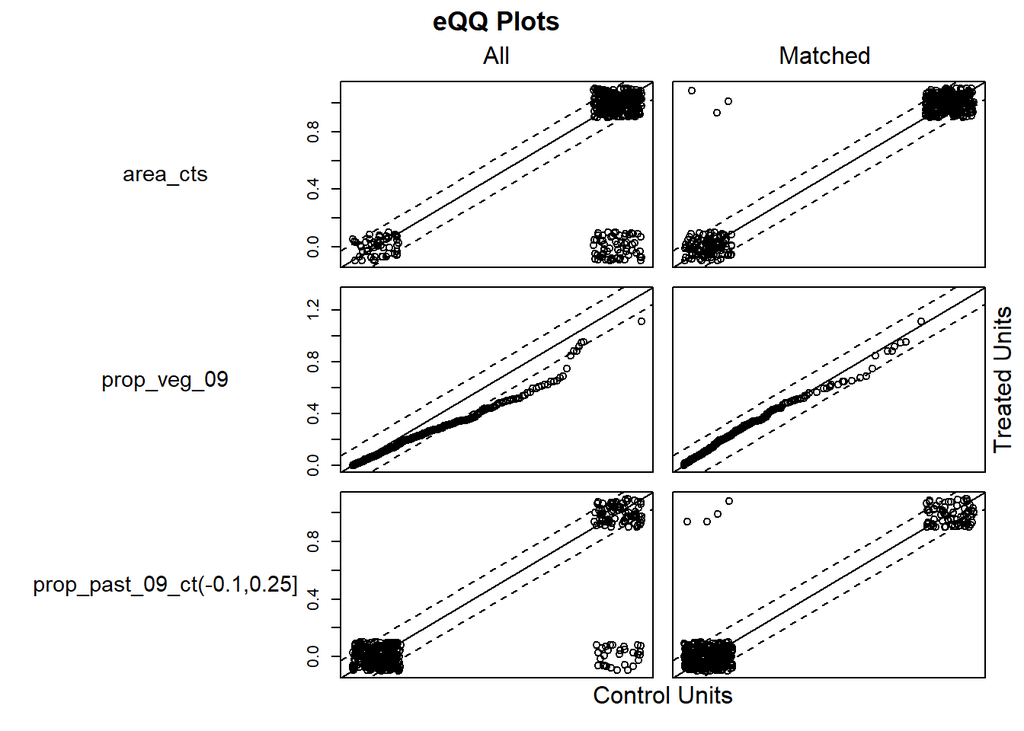

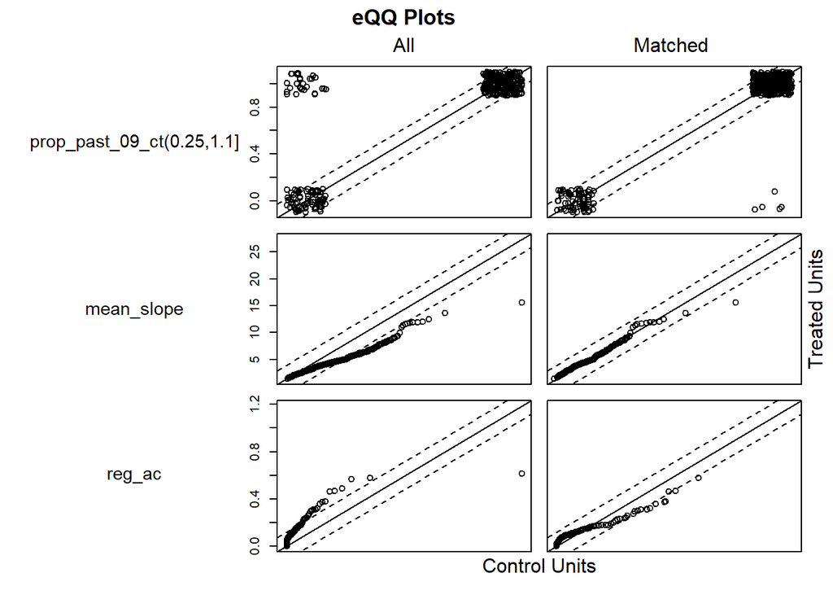

```r
plot(nn_ce)
```

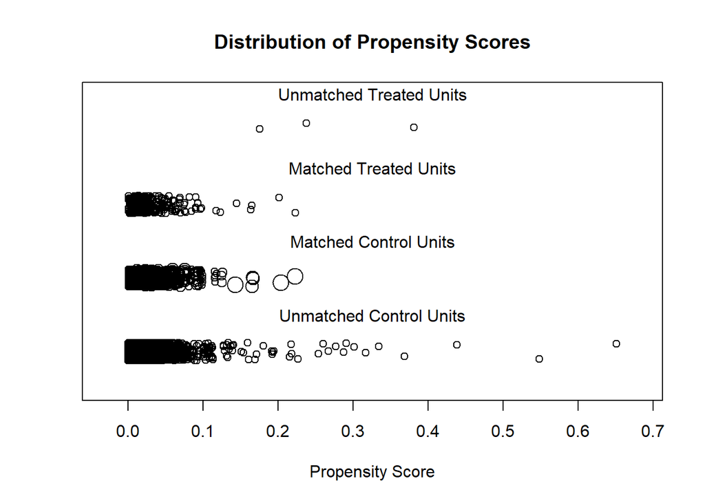

```
## [1] "To identify the units, use first mouse button; to stop, use second."
```

```
## integer(0)
```

```r
plot(nn_ce,"jitter")
```

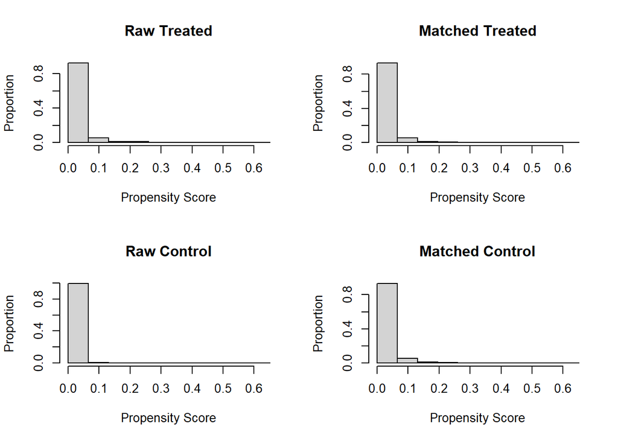

```r
plot(nn_ce,"hist")
```

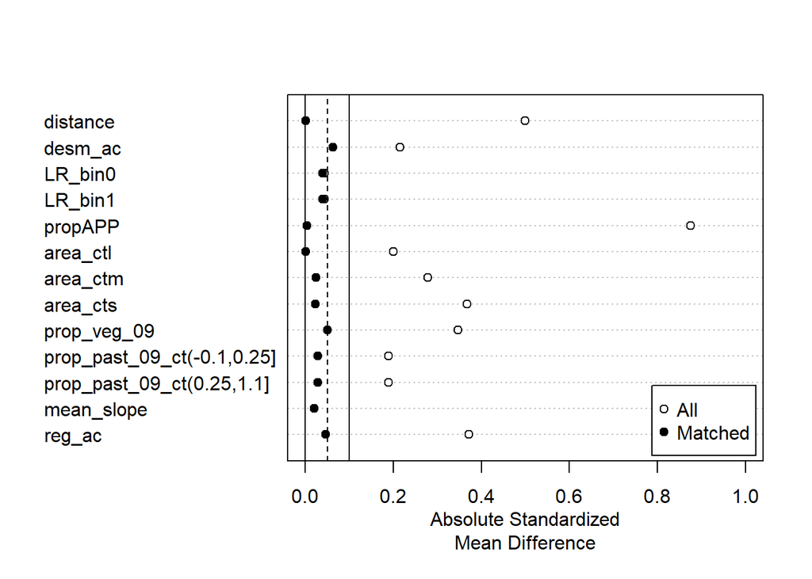

```r
plot(summary(nn_ce,standardize = TRUE),xlim=c(0,1))
```